# Лабораторная работа №2

Mathematics Typing и структура документа LaTeX

Оффеи Эндрю

Российский университет дружбы народов, Москва, Россия

Марта 2026

# Цель работы

# Основная цель

Изучение базовых и расширенных возможностей LaTeX для набора математических выражений и структурированного текста, включая:

- inline и display математический режим;
- индексы, греческие буквы и стандартные обозначения;
- нумерованные и многострочные уравнения;
- структурирование документа разделами и подразделами.

# Ход выполнения

# Среда и инструменты

В ходе работы использовались:

- дистрибутив **TeX Live 2025**;
- компилятор **pdflatex** (pdfTeX);
- стандартный класс документа `article`;
- пакет кодировок `fontenc`.

# Exercise 2.1.4

# Компиляция исходного файла

Файл `exercise_2_1_4.tex` был скомпилирован командой `pdflatex`.

Особенности вывода:

- загрузка класса `article` и `fontenc`;
- первый запуск без вспомогательного файла `.aux`;
- генерация шрифтов через `mktexpk`.

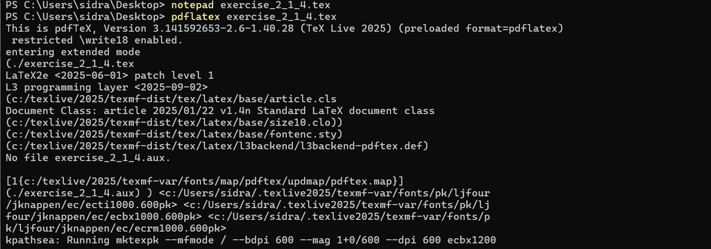

Компиляция exercise_2_1_4.tex

# Результат компиляции

Полученный документ `exercise_2_1_4.pdf` демонстрирует:

- разбиение текста на абзацы пустыми строками;
- сокращение множественных пробелов до одного;
- применение жирного и курсивного начертания;
- влияние неразрывных пробелов (например, в ссылках и инициалах).

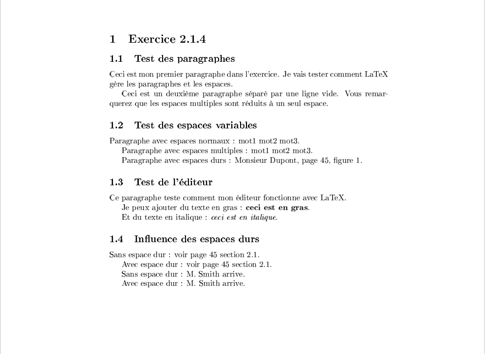

Результат exercise_2_1_4.pdf

# Дополнительная проверка оформления

Документ был просмотрен в увеличенном масштабе для контроля структуры и переносов строк.

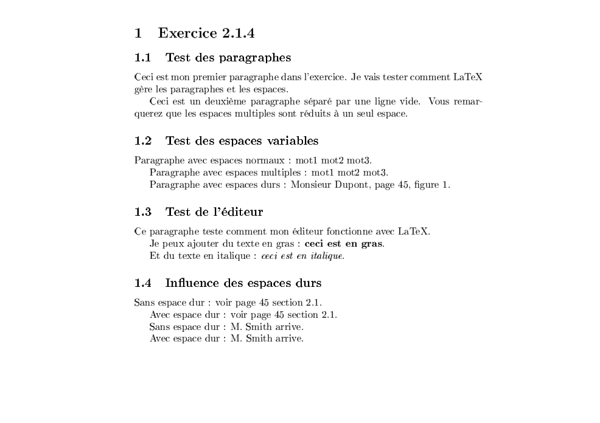

Просмотр результата Exercise 2.1.4

# Специальные символы

# Компиляция `special_chars.tex`

Файл `special_chars.tex` был скомпилирован с использованием `pdflatex`.

В выводе фиксируется:

- корректная загрузка `article` и `fontenc`;
- первый запуск без `.aux`;
- подключение и генерация шрифтовых ресурсов.

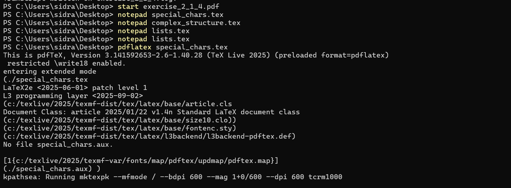

Компиляция special_chars.tex

# Списки

# Компиляция `lists.tex`

Файл `lists.tex` успешно скомпилирован.

Результат:

- создан `lists.pdf` (1 страница);
- сформирован журнал `lists.log`.

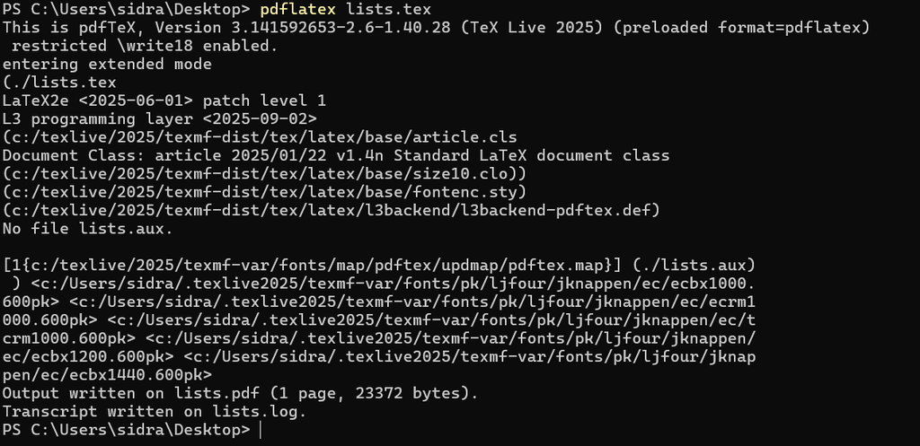

Компиляция lists.tex

# Mathematics Typing

# Пример `math1.pdf`

Документ демонстрирует:

- inline формулы внутри текста;
- display формулы отдельным блоком;
- нумерованное уравнение (`equation`);
- многострочные формулы с выравниванием.

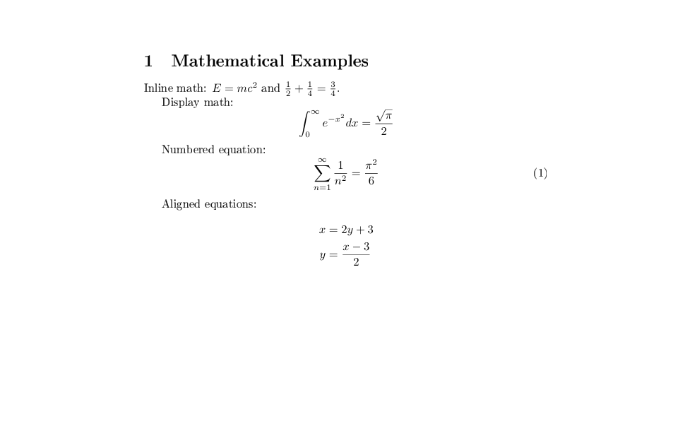

Mathematical Examples (math1.pdf)

# Пример `math2.pdf`

Во втором примере показано:

- сравнение inline и display режима;
- верхние и нижние индексы (`a^b`, `a_b`);
- греческие буквы (строчные и заглавные).

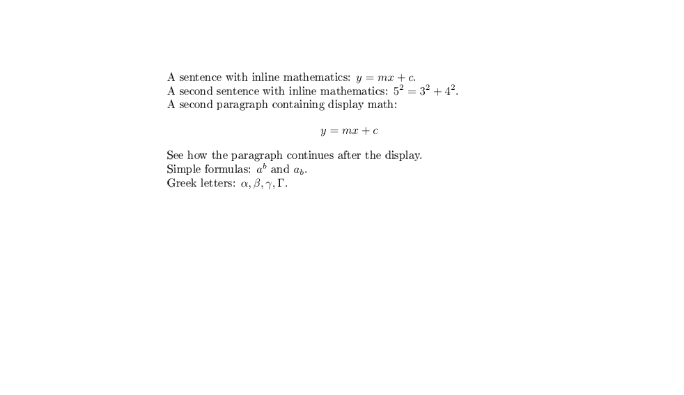

Inline/display и греческие буквы (math2.pdf)

# Структура документа

# Пример `structure.pdf`

Документ демонстрирует:

- использование `\section` и `\subsection`;
- автоматическую нумерацию разделов и подразделов;
- пример сноски.

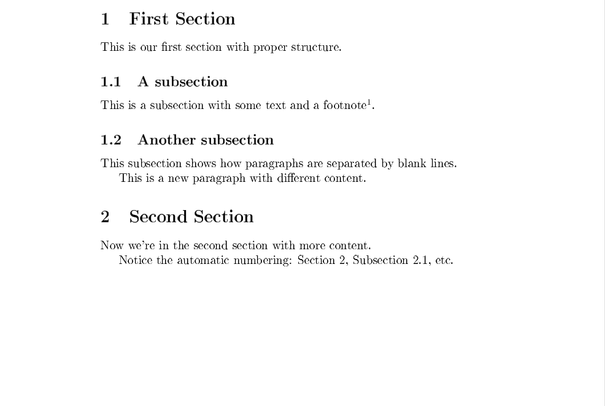

Проверка структуры документа (structure.pdf)

# Просмотр результатов

# Открытие PDF-файлов

После компиляции выполнено открытие и визуальная проверка документов:

- `structure.pdf`
- `math1.pdf`
- `math2.pdf`
- `exercise_2_1_4.pdf`

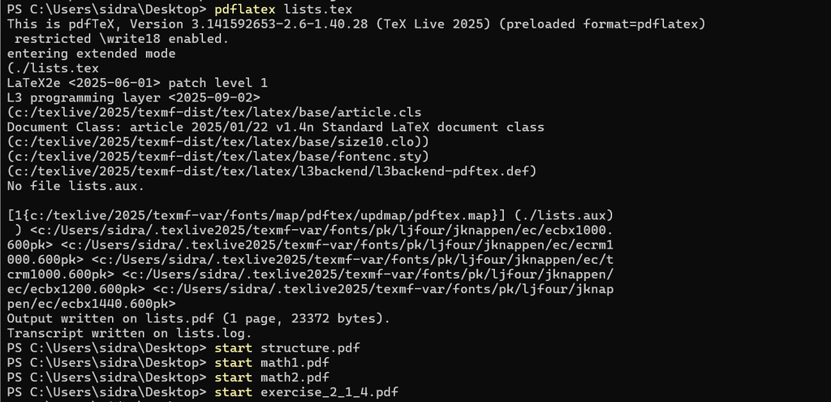

Открытие сгенерированных PDF-файлов

# Итоги работы

# Вывод

В ходе лабораторной работы были изучены и протестированы:

- правила оформления абзацев, пробелов и неразрывных пробелов;
- inline и display математический режим;
- индексы, греческие буквы и стандартные математические обозначения;
- нумерованные и многострочные уравнения;
- структурирование документа с разделами и подразделами.

Все `.tex`-файлы были корректно скомпилированы в **TeX Live 2025**, а полученные результаты соответствуют ожидаемому поведению LaTeX.